# Questions:

1. Adult females and children had preference in the lifeboats. Statistically speaking, was there more chance of survival if you were an adult female or a child rather than an adult male?
2. Was there a dependency in the survival rate given the social class in which each age category falls on, while age categories are Adult Females, Adult Males, and Children; and the social classes are 1, upper; 2, medium and; 3, lower.

# Description of Investigative Process:

1. I reviewed the data and the dictionary about its metadata to understand the sample more.
2. I brainstormed and formulated the first iteration of questions mentioned above. Initially, it was only one.
3. I set my scope by thinking on possible outcomes for this analysis.
4. Then I chose the method that I thought it was most applicable for this dataset: Naive Bayes Theorem.
5. I first categorized the data by using just the Sex. However, I thought it was going to be more meaningful if I change it to Age Category by adding children who are younger than 18. Thus, I modified the first question mentioned above.
6. I started validating the data by assigning Nones to any null value in affected columns. I converted any other data to the most appropriate data type.
7. Then, I decided which records to delete depending on how those data errors were going to affect my analysis.
8. I created the final table ready for analysis and investigate the results for final validation.
9. I started brainstorming for the best ways to visualize my data.
10. I iterated through different scenarios of visualization until I found the best-fitted ones.
11. I analyzed the visualization and came up with another question to ask. Thus, I added another question to the questions above.
12. I brainstormed the best ways to visualize the new question and how to improve the function to create the data frame to be fed to the visualizations.
13. I verified the data by manually checking probabilities and proportions manually on a white board by taking a sample of the sample.
14. I formulated the conclusions.

# Loading Dataset & Libraries:

### Importing Labraries

```python
import numpy as np
import pandas as pd
import matplotlib.pyplot as plt
import unicodecsv

#I got a warning when creating the Age Category column
#The warning does not affects the outcome, so we will ignore it
import warnings
warnings.filterwarnings('ignore')
```

### Importing Data

```python
titanic_filename = '/Users/sammy/Google Drive/Udacity/Data Analyst Nanodegree/Notebooks & Data/Titanic Analysis/Data Set/titanic-data.csv'
with open(titanic_filename, 'rb') as tit:
    reader = unicodecsv.DictReader(tit)
    titanic_sample = list(reader)
```

# Functions:

## 1. Data type conversion

```python
# Interates through values and if there is a blank instance returns none to avoid an error
# and it convert to the stated conversion type
# if no conversion is needed, just opt-out parse_type
def par_int_float_none(value, **parse_type):

    #When the user leaves the parse_type optional argument, the function will ignore it
    if parse_type['parse_type'] != {}:
        parse_type = parse_type['parse_type']['convertype']

    #Converts the values provided according to the parse_type
    #Return None for missing blank values
    #Return the same value type for opted-out parse_type
    if value == ' ' or value == '' or value == None:
        return None
    elif parse_type == 'float':
        return float(value)
    elif parse_type == 'int':
        return int(value)
    else:
        return value
```

```python
def convert_type(list_reader, header, **convertype):
    for rows in list_reader:
        rows[header] = par_int_float_none(rows[header], parse_type = convertype)
```

## 2. Invalid data on Frame & Cleaning

```python
#The formula will create a dataframe with only records with invalid data values for any given columns
#If the user order the header in a descending order, the records with more issues first, the less memory is used
#If the value is not None under a header, then it will move to the next header to find out validity
def invalid_to_frame(list_reader, *headers, **limit):

    #This variable will be the parameter to stop the loop
    #When the user decide to show only a limit of rows
    tolimit = 0

    list_values = []

    #It will loop vertically trhough the first header
    for rows in list_reader:
        if rows[headers[0]] == None:
            list_values.append(rows)
            tolimit += 1

        #It will loop horizontally trhough the next headers, same row and brake
        #Minimize getting in this loop by ordering the headers in a descending order of issues
        else:
            for i in range(len(headers)):
                if rows[headers[i]] == None:
                    list_values.append(rows)
                    tolimit += 1
                    enter = True
                    break


        #Condition will stop the loop at the limit provided
        #It will allow the user to select the number of rows included
        if limit != {}:
            if tolimit >= limit['limit']:
                break

    list_values_df = pd.DataFrame(list_values)

    return list_values_df
```

```python
#This formula will create a quick validation table with the difference
#between the count of records per column and the total record count
def validation_frame(dataframe, key):
    frame = pd.DataFrame(dataframe.count()-dataframe[key].count())
    frame.columns = ['Validation Issues']
    return frame
```

```python
#The function will provide only records not inlcuded in the invalid dataset provided
def clean_dataframe(indataframe, frominv_dataset, onkey):
    return indataframe.loc[~indataframe[onkey].isin(frominv_dataset[onkey])]
```

## 3. Proportion Creation from Frame to Numpy

```python
#This function will create a prorportion of each comparing_values by the categorize_value
#Index 0 is the data; index 1 are the keys, on the output array; and index 2 is the category size
from collections import OrderedDict
def ratio_groupby_tonumpy(data_frame, cat_array, what_toassess):

    # group data
    success_dat = data_frame.groupby(cat_array)[what_toassess].sum()
    total_dat = data_frame.groupby(cat_array)[what_toassess].count()
    split_count = len(data_frame.groupby(cat_array[len(cat_array)-1])[what_toassess].count())


    # calculate proportions
    ratio_calc = success_dat / total_dat


    # convert to numpy array
    np_prop_array = np.split(np.array(ratio_calc), split_count)

    # create list_unique
    cat_list = list(OrderedDict.fromkeys(success_dat.keys().get_level_values(0)))

    # number of categories
    cat_count = len(data_frame.groupby(cat_array)[what_toassess].count())

    # cat_list_full
    if len(cat_array) > 1:
        1
        combine_cat = list(success_dat.keys().get_level_values(0) + " Class " + success_dat.keys().get_level_values(1))
    else:
        combine_cat = 'To get combined categories, use an array with 2 values as the second parameter'

    return np_prop_array, cat_list, cat_count, combine_cat
```

## 4. Statistics Detail Data Frame

```python
#Creates a table of details statistics
def stat_detail_frame(data, category_array, what_toassess):

    #converting to series
    total = data.groupby(category_array)[what_toassess].count()
    partial = data.groupby(category_array)[what_toassess].sum()

    #Getting data into dataframe
    dataframe_conv = pd.DataFrame(total)

    #Creates and renames columns
    dataframe_conv.columns = ['Total Embarked']
    dataframe_conv.loc(axis = 1)['Total Survived'] = partial

    dataframe_conv.loc(axis = 1)['Total Died'] = dataframe_conv.iloc(axis = 0)[:, 0] - dataframe_conv.iloc(axis = 0)[:, 1]

    dataframe_conv.loc(axis = 1)['Survival Ratio'] = round((dataframe_conv.iloc(axis = 0)[:, 1] / dataframe_conv.iloc(axis = 0)\
                                                            [:, 0]), 2)

    dataframe_conv.loc(axis = 1)['Proportion of Ratio'] = round(dataframe_conv.iloc(axis = 0)[:, 3] / dataframe_conv.iloc(axis = 0)\
                                                 [:, 3].sum(), 4) * 100

    return dataframe_conv
```

# Converting Values and Assigning None:

```python
# This provides the dictionary keys available in a list
for key in titanic_sample[1]:
    print(key)
```

```
PassengerId
Survived
Pclass
Name
Sex
Age
SibSp
Parch
Ticket
Fare
Cabin
Embarked
```

```python
#Converts the data type to the given convertype and assings None for empty cells to aid in the validation process
#using pandas
convert_type(titanic_sample, 'PassengerId')
convert_type(titanic_sample, 'Survived', convertype = 'int')
convert_type(titanic_sample, 'Pclass')
convert_type(titanic_sample, 'Name')
convert_type(titanic_sample, 'Sex')
convert_type(titanic_sample, 'Age', convertype = 'float')
convert_type(titanic_sample, 'SibSp', convertype = 'int')
convert_type(titanic_sample, 'Parch', convertype = 'int')
convert_type(titanic_sample, 'Ticket')
convert_type(titanic_sample, 'Fare', convertype = 'float')
convert_type(titanic_sample, 'Cabin')
convert_type(titanic_sample, 'Embarked')
```

# Data Validation, Cleaning, & Wrangling:

## Validation

### 1. Converting to a DataFrame for validation

```python
# Coverting titanic_sample list to dataframe to prepare for validation
titanic_df = pd.DataFrame(titanic_sample)
```

### 2. Looking for missing values

```python
# Creating validation table to assess erroneous data using the stated function
vali_table = validation_frame(titanic_df, 'PassengerId')
vali_table
```

|  | Validation Issues |
| --- | --- |
| PassengerId | 0 |
| Survived | 0 |
| Pclass | 0 |
| Name | 0 |
| Sex | 0 |
| Age | -177 |
| SibSp | 0 |
| Parch | 0 |
| Ticket | 0 |
| Fare | 0 |
| Cabin | -687 |
| Embarked | -2 |

> > **Assessment:** *I have found that **177** values are missing under the Age, **2** under the Embarked, and **687** under the Cabin metadata.*

## Data Cleaning

```python
#Get the dataset with records that have invalid Age values
frominv_dataset = invalid_to_frame(titanic_sample, 'Age')

#Clean the dataset with records withot invalid Age values and create a clean dataframe table
titanic_df_clean = clean_dataframe(titanic_df, frominv_dataset,  onkey = 'PassengerId')
```

### 1. Creating a Clean DataFrame

```python
indataframe_count = pd.DataFrame(titanic_df_clean.count())
indataframe_count.columns = ['Total Count']
indataframe_count
```

|  | Total Count |
| --- | --- |
| PassengerId | 714 |
| Survived | 714 |
| Pclass | 714 |
| Name | 714 |
| Sex | 714 |
| Age | 714 |
| SibSp | 714 |
| Parch | 714 |
| Ticket | 714 |
| Fare | 714 |
| Cabin | 185 |
| Embarked | 712 |

### 2. Verifying that 177 records have been omitted

```python
#Create a validation dataframe table using the quick formula
vali_table_clean = validation_frame(dataframe = titanic_df_clean, key = 'PassengerId')
vali_table_clean
```

|  | Validation Issues |
| --- | --- |
| PassengerId | 0 |
| Survived | 0 |
| Pclass | 0 |
| Name | 0 |
| Sex | 0 |
| Age | 0 |
| SibSp | 0 |
| Parch | 0 |
| Ticket | 0 |
| Fare | 0 |
| Cabin | -529 |
| Embarked | -2 |

> > **Assessment:** *The 177 missing values in Age are gone. Those records are no longer included. We see a reduction of missing values in the Cabin metadata because they were not mutually exclusive and both are affected for the same removed records.*

## Descriptive Statistics for Age Data Wrangling

```python
sample_size = titanic_df['PassengerId'].count()
mean_age = titanic_df['Age'].mean()
median_age = titanic_df['Age'].median()
skew_age = titanic_df['Age'].skew()
max_age = titanic_df['Age'].max()
min_age = titanic_df['Age'].min()
description_age = titanic_df['Age'].describe()
```

```python
print('\
The sample size is {} \n\
The mean age is {:.2f} \n\
The median is {:.0f} \n\
The skew is {:.2f} \n\
The maximun value is {} \n\
The minimun value is {} '
      .format(sample_size, mean_age, median_age, skew_age, max_age, min_age))
```

```
The sample size is 891
The mean age is 29.70
The median is 28
The skew is 0.39
The maximun value is 80.0
The minimun value is 0.42
```

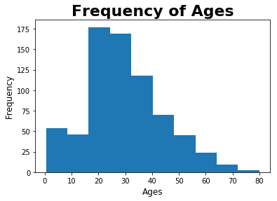

```python
plt.hist(titanic_df_clean['Age'])
plt.title('Frequency of Ages', size= 22, weight= 'bold')
plt.ylabel('Frequency', size = 12)
plt.xlabel('Ages', size = 12)
plt.show()
```

> > **Assessment:** *The distribution is a bit skewed to the right, a viewpoint strengthened by the .39 skewness descriptive value.*

## Wranglign Analysis on Cases

### 1. Cases without Age Wrangle

```python
# Creating a validation dataframe with the records with missing age data using the stated function
# Limiting to 10 rows to conserve space in the notebook
missing_age10 = invalid_to_frame(titanic_sample, 'Age', limit = 10)
missing_age10
```

|  | PassengerId | Survived | Pclass | Name | Sex | Age | SibSp | Parch | Ticket | Fare | Cabin | Embarked |
| --- | --- | --- | --- | --- | --- | --- | --- | --- | --- | --- | --- | --- |
| 0 | 6 | 0 | 3 | Moran, Mr. James | male | None | 0 | 0 | 330877 | 8.4583 | None | Q |
| 1 | 18 | 1 | 2 | Williams, Mr. Charles Eugene | male | None | 0 | 0 | 244373 | 13.0000 | None | S |
| 2 | 20 | 1 | 3 | Masselmani, Mrs. Fatima | female | None | 0 | 0 | 2649 | 7.2250 | None | C |
| 3 | 27 | 0 | 3 | Emir, Mr. Farred Chehab | male | None | 0 | 0 | 2631 | 7.2250 | None | C |
| 4 | 29 | 1 | 3 | O'Dwyer, Miss. Ellen "Nellie" | female | None | 0 | 0 | 330959 | 7.8792 | None | Q |
| 5 | 30 | 0 | 3 | Todoroff, Mr. Lalio | male | None | 0 | 0 | 349216 | 7.8958 | None | S |
| 6 | 32 | 1 | 1 | Spencer, Mrs. William Augustus (Marie Eugenie) | female | None | 1 | 0 | PC 17569 | 146.5208 | B78 | C |
| 7 | 33 | 1 | 3 | Glynn, Miss. Mary Agatha | female | None | 0 | 0 | 335677 | 7.7500 | None | Q |
| 8 | 37 | 1 | 3 | Mamee, Mr. Hanna | male | None | 0 | 0 | 2677 | 7.2292 | None | C |
| 9 | 43 | 0 | 3 | Kraeff, Mr. Theodor | male | None | 0 | 0 | 349253 | 7.8958 | None | C |

```python
missing_age = invalid_to_frame(titanic_sample, 'Age')
print( 'Validating that ' + str(missing_age['PassengerId'].count()) + ' values are missing')
```

```
Validating that 177 values are missing
```

> > > **Data Wranglign Notes:** *We found that 177 records in the sample had no Age data. This could have been because the passenger refused to provide such data, which could indicate (by suggestion and assuming that older people would refuse to provide their age to a stranger) that the age was too high if these values were not missing at random.*

> > > *An argument about this decision is that we can greatly create a bias by adding centralized values when the actual values could have been skewed and change the desired outcome, which is trying to predict the true proportions of survival or death depending on the Age Category, in the first scenario; and trying to predict the true proportions of survival or death depending on the Age Category and Social Class, in the second scenario.*

> > **Validation Assessment:** *In the data-frame above, records without age data would affect the rest of the analysis. Since Adult Females and Children were given preference on board the lifeboats, the hypothesis that Children and Adult Females had more chance of survival is applicable. This claim should be assessed to strengthen this claim.*

> **Action:** *Since there is no strong evidence that these null values under the age metadata were random or simply these people decided not to provide such information, these records will be omitted from the analysis to avoid creating a bias and changing our desired outcome.*

### 2. Cases without Cabin Wrangle

##### Creating a table to look for a relationship between Cabin and Ticket, Embarked, and Fare to see if we can determine the missing values in Cabin

```python
titanic_df.groupby(['Cabin' , 'Ticket', 'Fare', 'Embarked'])[['PassengerId']].count()
```

| Cabin | Ticket | Fare | Embarked | PassengerId |
| --- | --- | --- | --- | --- |
| A10 | 13049 | 40.1250 | C | 1 |
| A14 | 110465 | 52.0000 | S | 1 |
| A16 | 11755 | 39.6000 | C | 1 |
| A19 | 113056 | 26.0000 | S | 1 |
| A20 | PC 17485 | 56.9292 | C | 1 |
| A23 | 27042 | 30.0000 | S | 1 |
| A24 | PC 17590 | 50.4958 | S | 1 |
| A26 | 13213 | 35.5000 | C | 1 |
| A31 | 112277 | 31.0000 | C | 1 |
| A32 | 113767 | 50.0000 | S | 1 |
| A34 | 33638 | 81.8583 | S | 1 |
| A36 | 112050 | 0.0000 | S | 1 |
| A5 | PC 17754 | 34.6542 | C | 1 |
| A6 | 113788 | 35.5000 | S | 1 |
| A7 | 17764 | 30.6958 | C | 1 |
| B101 | PC 17755 | 512.3292 | C | 1 |
| B102 | 112058 | 0.0000 | S | 1 |
| B18 | 111361 | 57.9792 | C | 2 |
| B19 | 111240 | 33.5000 | S | 1 |
| B20 | 17474 | 57.0000 | S | 2 |
| B22 | WE/P 5735 | 71.0000 | S | 2 |
| B3 | 24160 | 211.3375 | S | 1 |
| B30 | 113509 | 61.9792 | C | 1 |
| B35 | PC 17477 | 69.3000 | C | 2 |
| B37 | 11771 | 29.7000 | C | 1 |
| B38 | 113050 | 26.5500 | S | 1 |
| B39 | 13568 | 49.5000 | C | 1 |
| B4 | PC 17610 | 27.7208 | C | 1 |
| B41 | 13567 | 79.2000 | C | 1 |
| B42 | 112053 | 30.0000 | S | 1 |
| ... | ... | ... | ... | ... |
| E25 | PC 17474 | 26.3875 | S | 1 |
| E31 | W.E.P. 5734 | 61.1750 | S | 1 |
| E33 | 113505 | 55.0000 | S | 2 |
| E34 | 16966 | 134.5000 | C | 1 |
| E36 | PC 17485 | 56.9292 | C | 1 |
| E38 | 13509 | 26.5500 | S | 1 |
| E40 | 16966 | 134.5000 | C | 1 |
| E44 | 13507 | 55.9000 | S | 2 |
| E46 | 17463 | 51.8625 | S | 1 |
| E49 | PC 17756 | 83.1583 | C | 1 |
| E50 | 11765 | 55.4417 | C | 1 |
| E58 | 5727 | 25.5875 | S | 1 |
| E63 | 111320 | 38.5000 | S | 1 |
| E67 | 110413 | 79.6500 | S | 2 |
| E68 | 110413 | 79.6500 | S | 1 |
| E77 | S.O./P.P. 3 | 10.5000 | S | 1 |
| E8 | 113806 | 53.1000 | S | 2 |
| F E69 | 2668 | 22.3583 | C | 1 |
| F G63 | 348121 | 7.6500 | S | 1 |
| F G73 | 348123 | 7.6500 | S | 1 |
|  | 348124 | 7.6500 | S | 1 |
| F2 | 230080 | 26.0000 | S | 3 |
| F33 | 248733 | 13.0000 | S | 1 |
|  | C.A. 29395 | 10.5000 | S | 1 |
|  | C.A. 34260 | 10.5000 | S | 1 |
| F38 | 383121 | 7.7500 | Q | 1 |
| F4 | 230136 | 39.0000 | S | 2 |
| G6 | 347054 | 10.4625 | S | 2 |
|  | PP 9549 | 16.7000 | S | 2 |
| T | 113784 | 35.5000 | S | 1 |

160 rows × 1 columns

##### Creating a table of Fare, Embarked, and Ticket of records with missing Cabin to crosscheck with previous table

```python
invalid_cabindf = invalid_to_frame(titanic_sample, 'Cabin')
invalid_cabindf.groupby(['Ticket' ,'Fare', 'Embarked'])[['Ticket']].count()
```

| Ticket | Fare | Embarked | Ticket |
| --- | --- | --- | --- |
| 111426 | 26.5500 | C | 1 |
| 111427 | 26.5500 | S | 1 |
| 111428 | 26.5500 | S | 1 |
| 112052 | 0.0000 | S | 1 |
| 112379 | 39.6000 | C | 1 |
| 113059 | 47.1000 | S | 1 |
| 113781 | 151.5500 | S | 1 |
| 113789 | 52.0000 | S | 2 |
| 113792 | 26.5500 | S | 1 |
| 113794 | 26.5500 | S | 1 |
| 113796 | 42.4000 | S | 1 |
| 113798 | 31.0000 | C | 1 |
|  |  | S | 1 |
| 113800 | 26.5500 | S | 1 |
| 113804 | 30.5000 | S | 1 |
| 113807 | 26.5500 | S | 1 |
| 11668 | 21.0000 | S | 2 |
| 12233 | 13.0000 | S | 1 |
| 12460 | 7.7500 | Q | 1 |
| 14311 | 7.7500 | Q | 1 |
| 14312 | 7.7500 | Q | 1 |
| 14313 | 7.7500 | Q | 1 |
| 14973 | 8.0500 | S | 1 |
| 1601 | 56.4958 | S | 7 |
| 17421 | 110.8833 | C | 1 |
| 19877 | 78.8500 | S | 1 |
| 19972 | 0.0000 | S | 1 |
| 2003 | 26.0000 | S | 1 |
| 211536 | 13.0000 | S | 1 |
| 21440 | 8.0500 | S | 1 |
| ... | ... | ... | ... |
| SOTON/OQ 3101317 | 7.2500 | S | 1 |
| SOTON/OQ 392076 | 7.0500 | S | 1 |
| SOTON/OQ 392082 | 8.0500 | S | 1 |
| SOTON/OQ 392086 | 8.0500 | S | 1 |
| SOTON/OQ 392089 | 8.0500 | S | 1 |
| SOTON/OQ 392090 | 8.0500 | S | 1 |
| STON/O 2. 3101269 | 7.9250 | S | 1 |
| STON/O 2. 3101273 | 7.1250 | S | 1 |
| STON/O 2. 3101274 | 7.1250 | S | 1 |
| STON/O 2. 3101275 | 7.1250 | S | 1 |
| STON/O 2. 3101280 | 7.9250 | S | 1 |
| STON/O 2. 3101285 | 7.9250 | S | 1 |
| STON/O 2. 3101286 | 7.9250 | S | 1 |
| STON/O 2. 3101288 | 7.9250 | S | 1 |
| STON/O 2. 3101289 | 7.9250 | S | 1 |
| STON/O 2. 3101292 | 7.9250 | S | 1 |
| STON/O 2. 3101293 | 7.9250 | S | 1 |
| STON/O 2. 3101294 | 7.9250 | S | 1 |
| STON/O2. 3101271 | 7.9250 | S | 1 |
| STON/O2. 3101279 | 15.8500 | S | 2 |
| STON/O2. 3101282 | 7.9250 | S | 1 |
| STON/O2. 3101283 | 7.9250 | S | 1 |
| STON/O2. 3101290 | 7.9250 | S | 1 |
| SW/PP 751 | 10.5000 | S | 1 |
| W./C. 14258 | 10.5000 | S | 1 |
| W./C. 14263 | 10.5000 | S | 1 |
| W./C. 6607 | 23.4500 | S | 2 |
| W./C. 6608 | 34.3750 | S | 4 |
| W./C. 6609 | 7.5500 | S | 1 |
| W/C 14208 | 10.5000 | S | 1 |

551 rows × 1 columns

##### Showing example of missing data

```python
# Creating a validation dataframe with the records with missing cabin data using the stated function
# Limiting to 10 rows to conserve space in the notebook
invalid_to_frame(titanic_sample, 'Cabin', limit = 10)
```

|  | PassengerId | Survived | Pclass | Name | Sex | Age | SibSp | Parch | Ticket | Fare | Cabin | Embarked |
| --- | --- | --- | --- | --- | --- | --- | --- | --- | --- | --- | --- | --- |
| 0 | 1 | 0 | 3 | Braund, Mr. Owen Harris | male | 22.0 | 1 | 0 | A/5 21171 | 7.2500 | None | S |
| 1 | 3 | 1 | 3 | Heikkinen, Miss. Laina | female | 26.0 | 0 | 0 | STON/O2. 3101282 | 7.9250 | None | S |
| 2 | 5 | 0 | 3 | Allen, Mr. William Henry | male | 35.0 | 0 | 0 | 373450 | 8.0500 | None | S |
| 3 | 6 | 0 | 3 | Moran, Mr. James | male | NaN | 0 | 0 | 330877 | 8.4583 | None | Q |
| 4 | 8 | 0 | 3 | Palsson, Master. Gosta Leonard | male | 2.0 | 3 | 1 | 349909 | 21.0750 | None | S |
| 5 | 9 | 1 | 3 | Johnson, Mrs. Oscar W (Elisabeth Vilhelmina Berg) | female | 27.0 | 0 | 2 | 347742 | 11.1333 | None | S |
| 6 | 10 | 1 | 2 | Nasser, Mrs. Nicholas (Adele Achem) | female | 14.0 | 1 | 0 | 237736 | 30.0708 | None | C |
| 7 | 13 | 0 | 3 | Saundercock, Mr. William Henry | male | 20.0 | 0 | 0 | A/5. 2151 | 8.0500 | None | S |
| 8 | 14 | 0 | 3 | Andersson, Mr. Anders Johan | male | 39.0 | 1 | 5 | 347082 | 31.2750 | None | S |
| 9 | 15 | 0 | 3 | Vestrom, Miss. Hulda Amanda Adolfina | female | 14.0 | 0 | 0 | 350406 | 7.8542 | None | S |

```python
missing_cabin = invalid_to_frame(titanic_sample, 'Cabin')
print( 'Validating that ' + str(missing_cabin['PassengerId'].count()) + ' values are missing')
```

```
Validating that 687 values are missing
```

> > > **Data Wranglign Notes:** *There are 687 missing values for the Cabin. One way of attempting to guess the Cabin letter and number is by identifying patterns within the data.*

> > > *In crosschecking the Fare and Ticket of records with missing Cabin values to those with Cabin values, there was no significant trend found that would help in providing an educative guess about the actual missin Cabin.*

> > **Validation Assessment:** *Records without cabin data will not affect the rest of the analysis. However, doing an assessment of the probability of survival given the deck level of the cabin is not possible with this missing data. The probability of survival of a person who was closer to the point of impact and at a lower level deck cannot be assessed due to missing too many of these fields since omitting 687 records out of 891 records will leave us with a sample of just 204. It is technically significant according to the central limit theorem, but we might be missing crucial data that could skew our results and create biases.*

> **Action:** *These records will not be omitted from the analysis.*

### 3. Cases without Embarked Wrangle

##### Creating a table to look for a relationship between Embarked and Ticket, Cabin, and Fare to see if we can determine the missing values in Embarked

```python
titanic_df.groupby(['Embarked' , 'Ticket', 'Cabin', 'Fare'])[['PassengerId']].count()
```

| Embarked | Ticket | Cabin | Fare | PassengerId |
| --- | --- | --- | --- | --- |
| C | 110813 | D37 | 75.2500 | 1 |
|  | 111361 | B18 | 57.9792 | 2 |
|  | 111369 | C148 | 30.0000 | 1 |
|  | 112277 | A31 | 31.0000 | 1 |
|  | 113051 | C111 | 27.7500 | 1 |
|  | 113503 | C82 | 211.5000 | 1 |
|  | 113509 | B30 | 61.9792 | 1 |
|  | 11755 | A16 | 39.6000 | 1 |
|  | 11765 | E50 | 55.4417 | 1 |
|  | 11767 | C50 | 83.1583 | 1 |
|  |  | C54 | 83.1583 | 1 |
|  | 11771 | B37 | 29.7000 | 1 |
|  | 11774 | C47 | 29.7000 | 1 |
|  | 11813 | D15 | 76.2917 | 1 |
|  | 11967 | B49 | 91.0792 | 2 |
|  | 13049 | A10 | 40.1250 | 1 |
|  | 13213 | A26 | 35.5000 | 1 |
|  | 13214 | B50 | 30.5000 | 1 |
|  | 13567 | B41 | 79.2000 | 1 |
|  | 13568 | B39 | 49.5000 | 1 |
|  | 16966 | E34 | 134.5000 | 1 |
|  |  | E40 | 134.5000 | 1 |
|  | 17421 | C68 | 110.8833 | 2 |
|  |  | C70 | 110.8833 | 1 |
|  | 17453 | C92 | 89.1042 | 2 |
|  | 17764 | A7 | 30.6958 | 1 |
|  | 2668 | F E69 | 22.3583 | 1 |
|  | 35273 | D36 | 113.2750 | 2 |
|  |  | D48 | 113.2750 | 1 |
|  | 36947 | D20 | 78.2667 | 2 |
| ... | ... | ... | ... | ... |
| S | 347054 | G6 | 10.4625 | 2 |
|  | 348121 | F G63 | 7.6500 | 1 |
|  | 348123 | F G73 | 7.6500 | 1 |
|  | 348124 | F G73 | 7.6500 | 1 |
|  | 35281 | D26 | 77.2875 | 2 |
|  | 36928 | C7 | 164.8667 | 1 |
|  | 36963 | D50 | 32.3208 | 1 |
|  | 36967 | D46 | 34.0208 | 1 |
|  | 36973 | C83 | 83.4750 | 2 |
|  | 392096 | E121 | 12.4750 | 2 |
|  | 5727 | E58 | 25.5875 | 1 |
|  | 695 | B51 B53 B55 | 5.0000 | 1 |
|  | C.A. 29395 | F33 | 10.5000 | 1 |
|  | C.A. 34260 | F33 | 10.5000 | 1 |
|  | F.C. 12750 | B71 | 52.0000 | 1 |
|  | PC 17473 | E25 | 26.2875 | 1 |
|  | PC 17474 | E25 | 26.3875 | 1 |
|  | PC 17475 | E24 | 26.2875 | 1 |
|  | PC 17476 | E24 | 26.2875 | 1 |
|  | PC 17483 | C95 | 221.7792 | 1 |
|  | PC 17582 | C125 | 153.4625 | 2 |
|  |  | C91 | 153.4625 | 1 |
|  | PC 17590 | A24 | 50.4958 | 1 |
|  | PC 17592 | D28 | 39.4000 | 1 |
|  | PC 17760 | C99 | 135.6333 | 1 |
|  | PP 9549 | G6 | 16.7000 | 2 |
|  | S.O./P.P. 3 | E77 | 10.5000 | 1 |
|  | SOTON/O.Q. 392078 | E10 | 8.0500 | 1 |
|  | W.E.P. 5734 | E31 | 61.1750 | 1 |
|  | WE/P 5735 | B22 | 71.0000 | 2 |

160 rows × 1 columns

##### Creating a table of Fare, Cabin, and Ticket of records with missing Embarked to crosscheck with previous table

```python
invalid_Embarkeddf = invalid_to_frame(titanic_sample, 'Embarked')
invalid_Embarkeddf.groupby(['Fare' ,'Ticket', 'Cabin'])[['Ticket']].count()
```

| Fare | Ticket | Cabin | Ticket |
| --- | --- | --- | --- |
| 80.0 | 113572 | B28 | 2 |

##### Showing example of missing values

```python
# Creating a validation dataframe with the records with missing embarked data using the stated function
# No limitation since the events meeting this criterion is short.
invalid_to_frame(titanic_sample, 'Embarked')
```

|  | PassengerId | Survived | Pclass | Name | Sex | Age | SibSp | Parch | Ticket | Fare | Cabin | Embarked |
| --- | --- | --- | --- | --- | --- | --- | --- | --- | --- | --- | --- | --- |
| 0 | 62 | 1 | 1 | Icard, Miss. Amelie | female | 38.0 | 0 | 0 | 113572 | 80.0 | B28 | None |
| 1 | 830 | 1 | 1 | Stone, Mrs. George Nelson (Martha Evelyn) | female | 62.0 | 0 | 0 | 113572 | 80.0 | B28 | None |

> > > **Data Wranglign Notes:** *There are 2 missing values for Embarked. These categorical values could have been missing at random. One way of attempting to guess the Cabin letter and number is by identifying patterns within the data.*

> > > *In crosschecking the Fare, Ticket, and Cabin of records with missing Embarked values to those with Embarked values, there was no significant trend found that would help in providing an educative guess about the actual missin Embarked.*

> > **Validation Assessment:** *Records without embarked data will not affect the rest of the analysis since the focus is not to know the population true proportions prediction of the ports from which the passengers embarked.*

> **Action:** *These records will not be omitted from the analysis.*

### Adding Age Category to the Data Frame using the loc Approach instead of Cut

```python
#Creating conditions
titanic_df_clean['Age Category'] = ''
condition = titanic_df_clean['Age'] >= 18
condition_male = titanic_df_clean['Sex'] == 'male'
condition_child = titanic_df_clean['Age'] <= 17

#Assigning respective Age Category depending on condition
titanic_df_clean.loc[condition, 'Age Category'] =  'Adult Females'
titanic_df_clean.loc[condition_male, 'Age Category'] =  'Adult Males'
titanic_df_clean.loc[condition_child, 'Age Category'] = 'Children'

#Printing DataFrame for visual assessment
titanic_df_clean
```

|  | PassengerId | Survived | Pclass | Name | Sex | Age | SibSp | Parch | Ticket | Fare | Cabin | Embarked | Age Category |
| --- | --- | --- | --- | --- | --- | --- | --- | --- | --- | --- | --- | --- | --- |
| 0 | 1 | 0 | 3 | Braund, Mr. Owen Harris | male | 22.0 | 1 | 0 | A/5 21171 | 7.2500 | None | S | Adult Males |
| 1 | 2 | 1 | 1 | Cumings, Mrs. John Bradley (Florence Briggs Th... | female | 38.0 | 1 | 0 | PC 17599 | 71.2833 | C85 | C | Adult Females |
| 2 | 3 | 1 | 3 | Heikkinen, Miss. Laina | female | 26.0 | 0 | 0 | STON/O2. 3101282 | 7.9250 | None | S | Adult Females |
| 3 | 4 | 1 | 1 | Futrelle, Mrs. Jacques Heath (Lily May Peel) | female | 35.0 | 1 | 0 | 113803 | 53.1000 | C123 | S | Adult Females |
| 4 | 5 | 0 | 3 | Allen, Mr. William Henry | male | 35.0 | 0 | 0 | 373450 | 8.0500 | None | S | Adult Males |
| 6 | 7 | 0 | 1 | McCarthy, Mr. Timothy J | male | 54.0 | 0 | 0 | 17463 | 51.8625 | E46 | S | Adult Males |
| 7 | 8 | 0 | 3 | Palsson, Master. Gosta Leonard | male | 2.0 | 3 | 1 | 349909 | 21.0750 | None | S | Children |
| 8 | 9 | 1 | 3 | Johnson, Mrs. Oscar W (Elisabeth Vilhelmina Berg) | female | 27.0 | 0 | 2 | 347742 | 11.1333 | None | S | Adult Females |
| 9 | 10 | 1 | 2 | Nasser, Mrs. Nicholas (Adele Achem) | female | 14.0 | 1 | 0 | 237736 | 30.0708 | None | C | Children |
| 10 | 11 | 1 | 3 | Sandstrom, Miss. Marguerite Rut | female | 4.0 | 1 | 1 | PP 9549 | 16.7000 | G6 | S | Children |
| 11 | 12 | 1 | 1 | Bonnell, Miss. Elizabeth | female | 58.0 | 0 | 0 | 113783 | 26.5500 | C103 | S | Adult Females |
| 12 | 13 | 0 | 3 | Saundercock, Mr. William Henry | male | 20.0 | 0 | 0 | A/5. 2151 | 8.0500 | None | S | Adult Males |
| 13 | 14 | 0 | 3 | Andersson, Mr. Anders Johan | male | 39.0 | 1 | 5 | 347082 | 31.2750 | None | S | Adult Males |
| 14 | 15 | 0 | 3 | Vestrom, Miss. Hulda Amanda Adolfina | female | 14.0 | 0 | 0 | 350406 | 7.8542 | None | S | Children |
| 15 | 16 | 1 | 2 | Hewlett, Mrs. (Mary D Kingcome) | female | 55.0 | 0 | 0 | 248706 | 16.0000 | None | S | Adult Females |
| 16 | 17 | 0 | 3 | Rice, Master. Eugene | male | 2.0 | 4 | 1 | 382652 | 29.1250 | None | Q | Children |
| 18 | 19 | 0 | 3 | Vander Planke, Mrs. Julius (Emelia Maria Vande... | female | 31.0 | 1 | 0 | 345763 | 18.0000 | None | S | Adult Females |
| 20 | 21 | 0 | 2 | Fynney, Mr. Joseph J | male | 35.0 | 0 | 0 | 239865 | 26.0000 | None | S | Adult Males |
| 21 | 22 | 1 | 2 | Beesley, Mr. Lawrence | male | 34.0 | 0 | 0 | 248698 | 13.0000 | D56 | S | Adult Males |
| 22 | 23 | 1 | 3 | McGowan, Miss. Anna "Annie" | female | 15.0 | 0 | 0 | 330923 | 8.0292 | None | Q | Children |
| 23 | 24 | 1 | 1 | Sloper, Mr. William Thompson | male | 28.0 | 0 | 0 | 113788 | 35.5000 | A6 | S | Adult Males |
| 24 | 25 | 0 | 3 | Palsson, Miss. Torborg Danira | female | 8.0 | 3 | 1 | 349909 | 21.0750 | None | S | Children |
| 25 | 26 | 1 | 3 | Asplund, Mrs. Carl Oscar (Selma Augusta Emilia... | female | 38.0 | 1 | 5 | 347077 | 31.3875 | None | S | Adult Females |
| 27 | 28 | 0 | 1 | Fortune, Mr. Charles Alexander | male | 19.0 | 3 | 2 | 19950 | 263.0000 | C23 C25 C27 | S | Adult Males |
| 30 | 31 | 0 | 1 | Uruchurtu, Don. Manuel E | male | 40.0 | 0 | 0 | PC 17601 | 27.7208 | None | C | Adult Males |
| 33 | 34 | 0 | 2 | Wheadon, Mr. Edward H | male | 66.0 | 0 | 0 | C.A. 24579 | 10.5000 | None | S | Adult Males |
| 34 | 35 | 0 | 1 | Meyer, Mr. Edgar Joseph | male | 28.0 | 1 | 0 | PC 17604 | 82.1708 | None | C | Adult Males |
| 35 | 36 | 0 | 1 | Holverson, Mr. Alexander Oskar | male | 42.0 | 1 | 0 | 113789 | 52.0000 | None | S | Adult Males |
| 37 | 38 | 0 | 3 | Cann, Mr. Ernest Charles | male | 21.0 | 0 | 0 | A./5. 2152 | 8.0500 | None | S | Adult Males |
| 38 | 39 | 0 | 3 | Vander Planke, Miss. Augusta Maria | female | 18.0 | 2 | 0 | 345764 | 18.0000 | None | S | Adult Females |
| ... | ... | ... | ... | ... | ... | ... | ... | ... | ... | ... | ... | ... | ... |
| 856 | 857 | 1 | 1 | Wick, Mrs. George Dennick (Mary Hitchcock) | female | 45.0 | 1 | 1 | 36928 | 164.8667 | None | S | Adult Females |
| 857 | 858 | 1 | 1 | Daly, Mr. Peter Denis | male | 51.0 | 0 | 0 | 113055 | 26.5500 | E17 | S | Adult Males |
| 858 | 859 | 1 | 3 | Baclini, Mrs. Solomon (Latifa Qurban) | female | 24.0 | 0 | 3 | 2666 | 19.2583 | None | C | Adult Females |
| 860 | 861 | 0 | 3 | Hansen, Mr. Claus Peter | male | 41.0 | 2 | 0 | 350026 | 14.1083 | None | S | Adult Males |
| 861 | 862 | 0 | 2 | Giles, Mr. Frederick Edward | male | 21.0 | 1 | 0 | 28134 | 11.5000 | None | S | Adult Males |
| 862 | 863 | 1 | 1 | Swift, Mrs. Frederick Joel (Margaret Welles Ba... | female | 48.0 | 0 | 0 | 17466 | 25.9292 | D17 | S | Adult Females |
| 864 | 865 | 0 | 2 | Gill, Mr. John William | male | 24.0 | 0 | 0 | 233866 | 13.0000 | None | S | Adult Males |
| 865 | 866 | 1 | 2 | Bystrom, Mrs. (Karolina) | female | 42.0 | 0 | 0 | 236852 | 13.0000 | None | S | Adult Females |
| 866 | 867 | 1 | 2 | Duran y More, Miss. Asuncion | female | 27.0 | 1 | 0 | SC/PARIS 2149 | 13.8583 | None | C | Adult Females |
| 867 | 868 | 0 | 1 | Roebling, Mr. Washington Augustus II | male | 31.0 | 0 | 0 | PC 17590 | 50.4958 | A24 | S | Adult Males |
| 869 | 870 | 1 | 3 | Johnson, Master. Harold Theodor | male | 4.0 | 1 | 1 | 347742 | 11.1333 | None | S | Children |
| 870 | 871 | 0 | 3 | Balkic, Mr. Cerin | male | 26.0 | 0 | 0 | 349248 | 7.8958 | None | S | Adult Males |
| 871 | 872 | 1 | 1 | Beckwith, Mrs. Richard Leonard (Sallie Monypeny) | female | 47.0 | 1 | 1 | 11751 | 52.5542 | D35 | S | Adult Females |
| 872 | 873 | 0 | 1 | Carlsson, Mr. Frans Olof | male | 33.0 | 0 | 0 | 695 | 5.0000 | B51 B53 B55 | S | Adult Males |
| 873 | 874 | 0 | 3 | Vander Cruyssen, Mr. Victor | male | 47.0 | 0 | 0 | 345765 | 9.0000 | None | S | Adult Males |
| 874 | 875 | 1 | 2 | Abelson, Mrs. Samuel (Hannah Wizosky) | female | 28.0 | 1 | 0 | P/PP 3381 | 24.0000 | None | C | Adult Females |
| 875 | 876 | 1 | 3 | Najib, Miss. Adele Kiamie "Jane" | female | 15.0 | 0 | 0 | 2667 | 7.2250 | None | C | Children |
| 876 | 877 | 0 | 3 | Gustafsson, Mr. Alfred Ossian | male | 20.0 | 0 | 0 | 7534 | 9.8458 | None | S | Adult Males |
| 877 | 878 | 0 | 3 | Petroff, Mr. Nedelio | male | 19.0 | 0 | 0 | 349212 | 7.8958 | None | S | Adult Males |
| 879 | 880 | 1 | 1 | Potter, Mrs. Thomas Jr (Lily Alexenia Wilson) | female | 56.0 | 0 | 1 | 11767 | 83.1583 | C50 | C | Adult Females |
| 880 | 881 | 1 | 2 | Shelley, Mrs. William (Imanita Parrish Hall) | female | 25.0 | 0 | 1 | 230433 | 26.0000 | None | S | Adult Females |
| 881 | 882 | 0 | 3 | Markun, Mr. Johann | male | 33.0 | 0 | 0 | 349257 | 7.8958 | None | S | Adult Males |
| 882 | 883 | 0 | 3 | Dahlberg, Miss. Gerda Ulrika | female | 22.0 | 0 | 0 | 7552 | 10.5167 | None | S | Adult Females |
| 883 | 884 | 0 | 2 | Banfield, Mr. Frederick James | male | 28.0 | 0 | 0 | C.A./SOTON 34068 | 10.5000 | None | S | Adult Males |
| 884 | 885 | 0 | 3 | Sutehall, Mr. Henry Jr | male | 25.0 | 0 | 0 | SOTON/OQ 392076 | 7.0500 | None | S | Adult Males |
| 885 | 886 | 0 | 3 | Rice, Mrs. William (Margaret Norton) | female | 39.0 | 0 | 5 | 382652 | 29.1250 | None | Q | Adult Females |
| 886 | 887 | 0 | 2 | Montvila, Rev. Juozas | male | 27.0 | 0 | 0 | 211536 | 13.0000 | None | S | Adult Males |
| 887 | 888 | 1 | 1 | Graham, Miss. Margaret Edith | female | 19.0 | 0 | 0 | 112053 | 30.0000 | B42 | S | Adult Females |
| 889 | 890 | 1 | 1 | Behr, Mr. Karl Howell | male | 26.0 | 0 | 0 | 111369 | 30.0000 | C148 | C | Adult Males |
| 890 | 891 | 0 | 3 | Dooley, Mr. Patrick | male | 32.0 | 0 | 0 | 370376 | 7.7500 | None | Q | Adult Males |

714 rows × 13 columns

> > **Assessment:** *All Age Categories have been assigned successfully. Now we can start grouping and visualizing.*

# Data Analysis: Visualizing Social Classes, Fare Buckets, and Gender

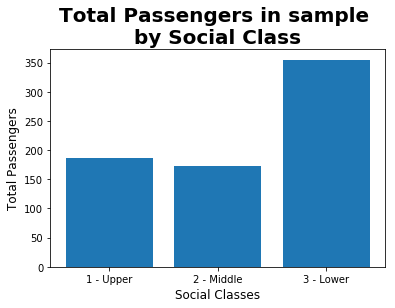

```python
# Calculating and assigning the ratio of survival vs total
pclass_grp = titanic_df_clean.groupby('Pclass')['Survived']
pclass_grp_count = pclass_grp.count() # Total of passengers
pclass_grp_sum = pclass_grp.sum() # Only passengers who survived
pclass_grp_rat = pclass_grp_sum/pclass_grp_count

# To place the bars according to the data size
y_pos = np.arange(len(pclass_grp_count))

# Plot creation for total
plt.bar(y_pos, pclass_grp_count)
plt.xticks(y_pos, ['1 - Upper', '2 - Middle', '3 - Lower'])
plt.title('Total Passengers in sample \nby Social Class', size = 20, weight = 'bold')
plt.xlabel('Social Classes', size = 12)
plt.ylabel('Total Passengers', size = 12)
plt.show()
```

> **Assessment:** *In general, there were more passengers in the lower class, as a representation of the poupulation.*

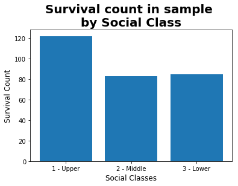

```python
# Plot creation for survival count
plt.bar(y_pos, pclass_grp_sum)
plt.xticks(y_pos, ['1 - Upper', '2 - Middle', '3 - Lower'])
plt.title('Survival count in sample \nby Social Class', size = 20, weight = 'bold')
plt.xlabel('Social Classes', size = 12)
plt.ylabel('Survival Count', size = 12)
plt.show()
```

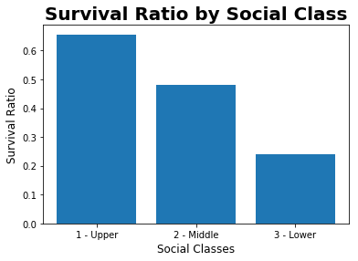

```python
# Plot creation for ratio
plt.bar(y_pos, pclass_grp_rat)
plt.xticks(y_pos, ['1 - Upper', '2 - Middle', '3 - Lower'])
plt.title('Survival Ratio by Social Class', size = 20, weight = 'bold')
plt.xlabel('Social Classes', size = 12)
plt.ylabel('Survival Ratio', size = 12)
plt.show()
```

> **Assessment:** *However, considering proportions, there was more change of survival if the passenger was in a higher Social Class, as a representation of the population. And the middle class had more chance of survival than the lower class.*

[figure not shown]

```python
pclass_grp = titanic_df_clean.groupby('Sex')['Survived']
pclass_grp_count = pclass_grp.count()
pclass_grp_sum = pclass_grp.sum()
pclass_grp_rat = pclass_grp_sum/pclass_grp_count

y_pos = np.arange(len(pclass_grp_count))

plt.bar(y_pos, pclass_grp_rat, color = ['pink', 'lightblue'])
plt.xticks(y_pos, ['Female', 'Male'])
plt.title('Survival Ratio by Social Class', size = 20, weight = 'bold')
plt.xlabel('Social Classes', size = 12)
plt.ylabel('Survival Ratio', size = 12)
plt.show()
```

> **Assessment:** *In general, there was more change of survival if the passenger was a Female, as a representation of the population.*

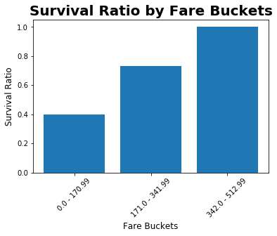

| Fare Buckets | Total |
| --- | --- |
| 0.0 - 170.99 | 696 |
| 171.0 - 341.99 | 15 |
| 342.0 - 512.99 | 3 |

```python
# Importing to round up the width
from math import ceil, floor

# Creating the bins
num_bins = 3
min_fare = titanic_df_clean['Fare'].min()
max_fare = titanic_df_clean['Fare'].max()
range_fare = max_fare-min_fare
bin_width = ceil(range_fare / num_bins)

# Final width array touches
bins_fare = np.arange(min_fare, (max_fare) + bin_width, (bin_width))

# Creating labels form array
label_bins = []
for x in range(0, len(bins_fare) - 1):
    label_bins.append(str(bins_fare[x]) + ' - ' + str(bins_fare[x] + bin_width - .01))

titanic_df_clean['Fare Buckets'] = pd.cut(round(titanic_df_clean['Fare'], 2), \
                                          right = False, bins = bins_fare, labels = label_bins)

# Calculating ratio of survival
fare_grouping = titanic_df_clean.groupby(['Fare Buckets'])['Survived']
fare_grp_count = fare_grouping.count() # Total passengers per fare buckets
fare_grp_sum = fare_grouping.sum() # Total passengers who survived per fare buckets
fare_grp_rat = fare_grp_sum / fare_grp_count

# Assigning the possition on the bars and bar labels
y_pos = np.arange(len(fare_grouping))

# Creating the plot
plt.bar(y_pos, fare_grp_rat)
plt.xticks(y_pos, label_bins, rotation = 45)
plt.title('Survival Ratio by Fare Buckets', size = 20, weight = 'bold')
plt.xlabel('Fare Buckets', size = 12)
plt.ylabel('Survival Ratio', size = 12)
plt.show()

# Showing a Data Frame to asses validity of sampling
fareBucket_df = pd.DataFrame(fare_grp_count)
fareBucket_df.columns = ['Total']
fareBucket_df
```

> **Assessment:** *The survival ratio was higher for high-paying passengers. However, this probability is not representative since there are only 3 passengers that bough tickets at a fare higher than 342. To address this issue a higher sample should be collected.*

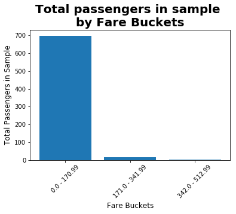

| Fare Buckets | Pclass | Survived |
| --- | --- | --- |
| 0.0 - 170.99 | 1 | 168 |
|  | 2 | 173 |
|  | 3 | 355 |
| 171.0 - 341.99 | 1 | 15 |
| 342.0 - 512.99 | 1 | 3 |

```python
# Creating the plot to see the price (Fare) distribution
plt.bar(y_pos, fare_grp_count)
plt.xticks(y_pos, label_bins, rotation = 45)
plt.title('Total passengers in sample \nby Fare Buckets', size = 20, weight = 'bold')
plt.xlabel('Fare Buckets', size = 12)
plt.ylabel('Total Passengers in Sample', size = 12)
plt.show()

# Data Frame to see the group the fare buckets by social classes
pd.DataFrame(titanic_df_clean.groupby(['Fare Buckets', 'Pclass'])['Survived'].count())
```

> **Assessment:** *Regardless of survival rate, most of the fares were bought at a lower price even by high Social Classes. Thus, Fare Buckets will not be good indicator of factors that increased the survival rate. The focus will go the Social Classes and Age Category.*

# Data Analysis: Visualizing Age Category and Social Classes

### Survival Proportions by Age Category

#### 1. Simple Statistics Detail Table

```python
# Creating simple statistics details into a dataframe from the stated function
stat_detail_frame(titanic_df_clean, ['Age Category'], 'Survived')
```

| Age Category | Total Embarked | Total Survived | Total Died | Survival Ratio | Proportion of Ratio |
| --- | --- | --- | --- | --- | --- |
| Adult Females | 206 | 159 | 47 | 0.77 | 51.68 |
| Adult Males | 395 | 70 | 325 | 0.18 | 12.08 |
| Children | 113 | 61 | 52 | 0.54 | 36.24 |

**Dictionary:**

Total Embarked: Thi is the total of people in the sample of interest.

Total Survived: This is the total of people who survived in the sample of interest.

Total Died: This is the total of people who died in the sample of interest.

Proportion of Ratio: This is the proportion of the probabilities.

#### 2. Survival Ratio Bar Chart

```python
# assigning the survival ratios (naive Bayes probabilities) to fit in the bar chart from the stated function
survival_ratio_age = ratio_groupby_tonumpy(titanic_df_clean, ['Age Category'], 'Survived')
```

```python
survival_ratio_age[1]
```

```
['Adult Females', 'Adult Males', 'Children']
```

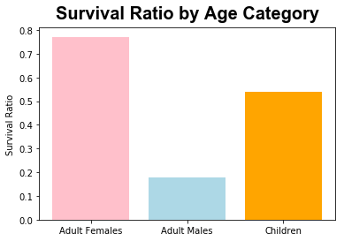

```python
#Assigning plot arguments
objects = survival_ratio_age[1]
y_pos = np.arange(len(objects))
performance = survival_ratio_age[0]

#Fonts & Format
title_font = {'fontname':'Arial', 'size':'20', 'color':'black', 'weight':'bold',
              'verticalalignment':'bottom'}

colors = ['pink', 'lightblue', 'orange']

#Plot
plt.bar(y_pos, performance, align='center', alpha=1, color=colors)
plt.xticks(y_pos, objects)
plt.ylabel('Survival Ratio')
plt.title('Survival Ratio by Age Category', title_font)

plt.show()
```

> > **Assessment:** *We can see that the probability of being an Adult Female who survived is the highest of all. Also, the probability of being a Child (younger than 18 years) who survived is higher than that of an Adult Male. The sample size is 714 sailors; therefore, it is quite representative of the population. However, we should investigate further by comparing the significant difference between the proportions.*

#### 3. Survival Ratio Proportion Pie

```python
# calculating the proportions of the survival ratio (naive Bayes probabilities) to use on pie
Prop_ratio_age = survival_ratio_age[0]/sum(survival_ratio_age[0])
```

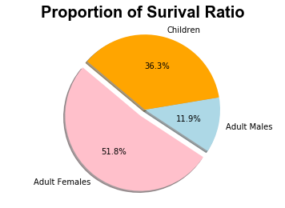

```python
#Proportion of ratios
np_prop_ratios = Prop_ratio_age

# Data to plot
labels = survival_ratio_age[1]
sizes = np_prop_ratios
colors = ['pink', 'lightblue', 'orange']
explode = (0.1, 0.0, 0.0)  # explode 1st slice

# Font
title_font = {'fontname':'Arial', 'size':'20', 'color':'black', 'weight':'bold',
              'verticalalignment':'bottom'}

# Plot
plt.title('Proportion of Surival Ratio' , title_font)
plt.pie(sizes, explode=explode, labels=labels, colors=colors,
        autopct='%1.1f%%', shadow=True, startangle=140)

plt.axis('equal')
plt.show()
```

> > **Assessment:** *With this pie, we can clearly see the difference in the probabilities of survival given the Age Category. We can corroborate the claim that women and children were given priority over men. However, was this dependent on their social class, I wonder.*

# Survival Proportions by Age Category and Social Class

#### 1. Simple Statistics Detail Table

```python
# Creating simple statistics details into a dataframe from the stated function
stat_detail_frame(titanic_df_clean, ['Age Category', 'Pclass'], 'Survived')
```

| Age Category | Pclass | Total Embarked | Total Survived | Total Died | Survival Ratio | Proportion of Ratio |
| --- | --- | --- | --- | --- | --- | --- |
| Adult Females | 1 | 77 | 75 | 2 | 0.97 | 19.17 |
|  | 2 | 62 | 56 | 6 | 0.90 | 17.79 |
|  | 3 | 67 | 28 | 39 | 0.42 | 8.30 |
| Adult Males | 1 | 97 | 36 | 61 | 0.37 | 7.31 |
|  | 2 | 88 | 6 | 82 | 0.07 | 1.38 |
|  | 3 | 210 | 28 | 182 | 0.13 | 2.57 |
| Children | 1 | 12 | 11 | 1 | 0.92 | 18.18 |
|  | 2 | 23 | 21 | 2 | 0.91 | 17.98 |
|  | 3 | 78 | 29 | 49 | 0.37 | 7.31 |

**Dictionary:**

Columns: Same as prevous table

Pclass: The social classes, which are 1, high; 2, medium; and 3, low.

#### 2. Survival Ratio Bar Chart

```python
# assigning the survival ratios (naive Bayes probabilities) to fit in the bar chart from the stated function
survival_ratio_age_pclass = ratio_groupby_tonumpy(titanic_df_clean, ['Age Category', 'Pclass'], 'Survived')
```

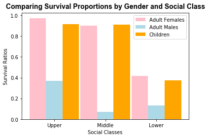

```python
# data to plot
n_groups = len(survival_ratio_age_pclass[0])

# create plot
fig, ax = plt.subplots()
index = np.arange(n_groups)
bar_width = n_groups/survival_ratio_age_pclass[2]-.01
opacity = 1
colors = ['pink', 'lightblue', 'orange']

# fonts

title_font = {'fontname':'Arial', 'size':'14', 'color':'black', 'weight':'bold',
              'verticalalignment':'bottom'}


for i in range(len(survival_ratio_age_pclass[0])):
    plt.bar((index + bar_width * i), survival_ratio_age_pclass[0][i], bar_width,\
                     alpha=opacity,\
                     color=colors[i],\
                     label=survival_ratio_age_pclass[1][i])


plt.xlabel('Social Classes')
plt.ylabel('Survival Ratios')
plt.title('Comparing Survival Proportions by Gender and Social Class', title_font)
plt.xticks(index + bar_width, ('Upper', 'Middle', 'Lower'))
plt.legend()

plt.tight_layout()
plt.show()
```

> > **Assessment:** *When we add the social class statuses to the mix, we can no longer see a huge difference between being an Adult Female or a Child who survived within the same social class. However, we can see the differences between Adult Females and Children who survived and Adult Males who survived.*

#### 3. Survival Ratio Proportion Pie Chart

```python
# calculating the proportions of the survival ratio (naive Bayes probabilities) to use on pie
prop_ratio_age_pcalss = np.array(survival_ratio_age_pclass[0]).reshape(9, 1) / \
                            np.array(survival_ratio_age_pclass[0]).reshape(9, 1).sum()
```

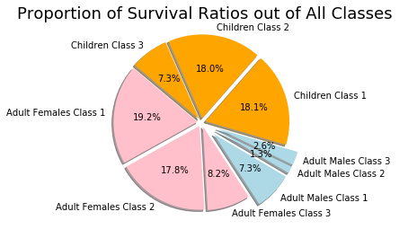

```python
#Proportion of ratios
np_prop_ratios = prop_ratio_age_pcalss

# Data to plot
labels = survival_ratio_age_pclass[3]
sizes = np_prop_ratios
colors = ['pink', 'pink', 'pink', 'lightblue', 'lightblue', 'lightblue', 'orange', 'orange', 'orange']
explode = (0.05, 0.05, 0.05, 0.2, 0.2, 0.2, 0.05, 0.05, 0.05)  #explode all slices

# Plot
plt.title('Proportion of Survival Ratios out of All Classes', size=18)
plt.pie(sizes, explode=explode, labels=labels, colors=colors,
        autopct='%1.1f%%', shadow=True, startangle=140)

plt.axis('equal')
plt.show()
```

> > **Assessment:** *In this sample, we can see that Adult Males had less chance of survival in general and those in higher social classes had more chance of survival, with the exception of Adult Males in social classes 2 and 3. The probabilities do not seem to have enough significance difference. A further analysis must be done to determine the significant difference between the two probabilities. The same applies to Adult Females and to Children in classes 1 and 2.*

```python
array_surv_proportions = np.array(survival_ratio_age_pclass[0]) / sum(np.array(survival_ratio_age_pclass[0]))
```

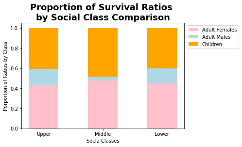

```python
N = 5
adult_females = array_surv_proportions[0]
adult_males = array_surv_proportions[1]
children = array_surv_proportions[2]


ind = np.arange(len(np.array(survival_ratio_age_pclass[0])[0]))   # the x locations for the groups
width = .5     # the width of the bars: can also be len(x) sequence

p1 = plt.bar(ind, adult_females, width, color='pink')
p2 = plt.bar(ind, adult_males, width, bottom=adult_females, color='lightblue')
p3 = plt.bar(ind, children, width, bottom=adult_males + adult_females, color='orange')

plt.ylabel('Porportion of Ratios by Class')
plt.xlabel('Socla Classes')
plt.title('Proportion of Survival Ratios \nby Social Class Comparison', size=18, weight='bold')
plt.xticks(ind, ('Upper', 'Middle', 'Lower'))
plt.legend(('Adult Females', 'Adult Males', 'Children'), bbox_to_anchor=(1, 1))

plt.show()
```

> > **Assessment:** *Within social classes, we see that Children and Adult Females were predominant in the survival rate. Adult Males had less chance of survival within social classes, with even less chance within only the middle class.*

# Conclusion

In conclusion, based on the Naive Bayes Theorem, there is more likelihood that an Adult Female will have more chances of survival than Children and Adult Males. However, although the likelihood of being an Adult Female who survived is greater than that of being a Child who survived, the differences between both may not have enough significant difference. A further hypothesis test of their proportions is recommended.

Nevertheless, to answer our first question, there is strong visual evidence that Adult Females and Children had more chance of survival than men.

# Sources

http://www.Stackoverflow.com

Live Help

Project Review

http://www.tutorialspoint.com

http://www.pandas.pydata.org

http://www.pythonspot.com

http://www.statisticssolutions.com/missing-values-in-data/

https://pyformat.info/

http://matplotlib.org/examples/pylab_examples/bar_stacked.html